# Курсовая работа № 2

#### 4.4 Проверка возможных зависимостей по шкале 'специальности' (position)

```python
# Показатели для графика приводятся по масштабу
# cost_performance_unit - стоимость единицы квалификации в области, специальности (приведенная к масштабу)
position = pd.read_sql("""SELECT
                                position AS position,
                                AVG(perf_scoreid) AS perf_scoreid_avg,
                                AVG("Pay Rate")/10 AS Pay_Rate,
                                AVG("Pay Rate")/2 / AVG(perf_scoreid) AS cost_performance_unit
                           FROM hr_dataset
                               WHERE "Employment Status"='Active'  AND perf_scoreid >1 AND perf_scoreid <9
                                    GROUP BY position
                                            ORDER BY Pay_Rate DESC  """, connect)
position.index = position.position
position = position.drop(['position'], axis = 1)
position
```

| position | perf_scoreid_avg | pay_rate | cost_performance_unit |
| --- | --- | --- | --- |
| President & CEO | 3.000000 | 8.000000 | 13.333333 |
| IT Director | 5.000000 | 6.500000 | 6.500000 |
| CIO | 5.000000 | 6.500000 | 6.500000 |
| IT Manager - Support | 4.000000 | 6.400000 | 8.000000 |
| BI Director | 3.000000 | 6.350000 | 10.583333 |
| IT Manager - Infra | 2.000000 | 6.300000 | 15.750000 |
| IT Manager - DB | 3.000000 | 6.200000 | 10.333333 |
| Director of Operations | 4.000000 | 6.000000 | 7.500000 |
| Director of Sales | 3.000000 | 6.000000 | 10.000000 |
| Area Sales Manager | 3.052632 | 5.526316 | 9.051724 |
| Sales Manager | 2.500000 | 5.500000 | 11.000000 |
| Data Architect | 3.000000 | 5.500000 | 9.166667 |
| Shared Services Manager | 3.000000 | 5.500000 | 9.166667 |
| Production Manager | 3.111111 | 5.361111 | 8.616071 |
| Senior BI Developer | 3.000000 | 5.116667 | 8.527778 |
| Software Engineer | 3.500000 | 5.009000 | 7.155714 |
| BI Developer | 3.000000 | 4.525000 | 7.541667 |
| Database Administrator | 4.333333 | 3.926667 | 4.530769 |
| Network Engineer | 3.000000 | 3.766667 | 6.277778 |
| Sr. Accountant | 3.000000 | 3.495000 | 5.825000 |
| IT Support | 3.250000 | 2.847000 | 4.380000 |
| Software Engineering Manager | 3.000000 | 2.700000 | 4.500000 |
| Accountant I | 3.000000 | 2.683333 | 4.472222 |
| Production Technician II | 3.300000 | 2.506200 | 3.797273 |
| Production Technician I | 3.166667 | 1.897933 | 2.996737 |

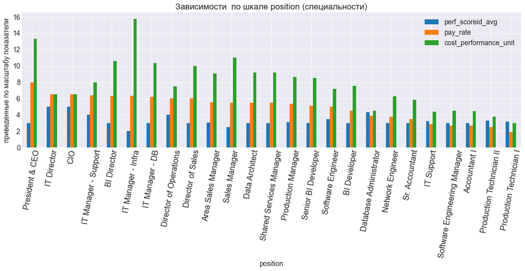

```python
plt.rcParams["figure.figsize"] = (18, 5)

matplotlib.rc('xtick', labelsize=16)
matplotlib.rc('ytick', labelsize=14)
plt.rcParams.update({'font.size': 14})

position.plot.bar()
plt.title("Зависимости  по шкале position (специальности)", fontsize=17) # ШРИФТ
plt.ylabel('приведенные по масштабу показатели')
plt.xticks(rotation=80)
plt.show()
```

##### 4.4.1 Гипотезы зависимостей по принадлежности персонала к специальности (position)

*1) Есть зависимость по шкале position: чем ДАЛЬШЕ ОТ ПРОИЗВОДСТВА в сторону УПРАВЛЕНИЯ и ПРОДАЖ - тем ВЫШЕ ОПЛАТА (см. pay_rate).*  
*2) Есть зависимость по шкале position : при относительном постоянстве самой величины perf_scoreid_avg, чем БЛИЖЕ К ПРОИЗВОДСТВУ (c'est la vie) - тем НИЖЕ стоимость (или рыночная цена) ЕДИНИЦЫ КВАЛИФИКАЦИИ = Performance (perf_scoreid).*  
*3) ! Есть зависимость по шкале position : при ВЕСЬМА НИЗКОЙ perf_scoreid_avg, НАИБОЛЬШУЮ стоимость (или рыночную цену) ЕДИНИЦЫ Performance (perf_scoreid) имеет специальности, связанные с IT-технологиями ("IT Manager - Infra") и продажами ("Sales Manager") даже в ущерб общего руководства.*

#### 4.5 Проверка возможных зависимостей по шкале ВОЗРАСТ (age)

```python
age1 = pd.read_sql("""SELECT
                                age AS age,
                                AVG(perf_scoreid) AS perf_scoreid_avg,
                                AVG("Pay Rate")/10 AS Pay_Rate
                       FROM hr_dataset
                               WHERE "Employment Status"='Active'  AND perf_scoreid >1 AND perf_scoreid <9
                                    GROUP BY age
                                            ORDER BY age  """, connect)
age1.index = age1.age
age1 = age1.drop(['age'], axis = 1)
age1
```

| age | perf_scoreid_avg | pay_rate |
| --- | --- | --- |
| 25 | 3.000000 | 2.200000 |
| 27 | 2.666667 | 3.266667 |
| 28 | 3.200000 | 4.560000 |
| 29 | 3.363636 | 4.159091 |
| 30 | 3.000000 | 3.754333 |
| 31 | 3.000000 | 2.905556 |
| 32 | 3.000000 | 2.484500 |
| 33 | 3.333333 | 3.033333 |
| 34 | 3.250000 | 2.859500 |
| 35 | 3.500000 | 3.066667 |
| 36 | 3.285714 | 4.223571 |
| 37 | 3.500000 | 4.375000 |
| 38 | 3.250000 | 3.337500 |
| 39 | 2.900000 | 2.490500 |
| 40 | 3.000000 | 2.750000 |
| 41 | 4.000000 | 2.100000 |
| 42 | 2.666667 | 4.266667 |
| 43 | 3.000000 | 2.300000 |
| 44 | 3.250000 | 2.731250 |
| 45 | 3.200000 | 3.729800 |
| 46 | 3.000000 | 6.350000 |
| 47 | 3.250000 | 3.950000 |
| 48 | 4.250000 | 2.956250 |
| 49 | 3.000000 | 3.885000 |
| 50 | 4.000000 | 5.500000 |
| 51 | 3.333333 | 2.200000 |
| 52 | 3.000000 | 4.050000 |
| 53 | 3.000000 | 3.975000 |
| 54 | 3.333333 | 3.200000 |
| 55 | 3.000000 | 5.500000 |
| 56 | 3.000000 | 1.600000 |
| 59 | 3.000000 | 2.200000 |
| 63 | 3.000000 | 6.775000 |
| 67 | 3.000000 | 1.600000 |

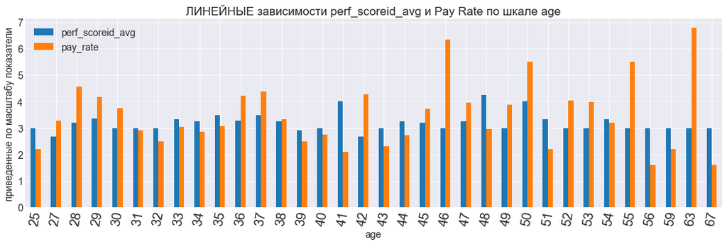

```python
plt.rcParams["figure.figsize"] = (18, 5)

matplotlib.rc('xtick', labelsize=19)
matplotlib.rc('ytick', labelsize=14)
plt.rcParams.update({'font.size': 14})

age1.plot.bar()
plt.title("ЛИНЕЙНЫЕ зависимости perf_scoreid_avg и Pay Rate по шкале age", fontsize=17) # ШРИФТ
plt.ylabel('приведенные по масштабу показатели')
plt.xticks(rotation=80)
plt.show()
```

```python
# ВИДНЫ 4(ЧЕТЫРЕ) ИНТЕРВАЛА НА ШКАЛЕ AGE: 25-32, З3-41, 42-51, 52-67 ЛЕТ.
# ПРОСЛЕДИТЬ ХАРАКТЕР ЗАВИСИМОСТИ  perf_scoreid_avg / Pay Rate ВНУТРИ КАЖДОГО ИНТЕРВАЛА :
```

```python
age_perf = pd.read_sql("""SELECT
                               ROUND(AVG(CASE WHEN age BETWEEN 24 AND 33 THEN perf_scoreid END),1) as "25-32 years",
                               ROUND(AVG(CASE WHEN age BETWEEN 32 AND 42 THEN perf_scoreid END),1) as "33-41 years ",
                               ROUND(AVG(CASE WHEN age BETWEEN 41 AND 52 THEN perf_scoreid END),1) as "42-51 years",
                               ROUND(AVG(CASE WHEN age BETWEEN 51 AND 68 THEN perf_scoreid END),1) as "52-67 years"
                          FROM hr_dataset
                              WHERE "Employment Status"='Active'  AND perf_scoreid >1 AND perf_scoreid <9
                                 """, connect)

age_perf
```

|  | 25-32 years | 33-41 years | 42-51 years | 52-67 years |
| --- | --- | --- | --- | --- |
| 0 | 3.1 | 3.2 | 3.3 | 3.1 |

```python
age_pay = pd.read_sql("""SELECT
                               ROUND(AVG(CASE WHEN age BETWEEN 24 AND 33 THEN "Pay Rate" END)) as "25-32 years",
                               ROUND(AVG(CASE WHEN age BETWEEN 32 AND 42 THEN "Pay Rate" END)) as "33-41 years ",
                               ROUND(AVG(CASE WHEN age BETWEEN 41 AND 52 THEN "Pay Rate" END)) as "42-51 years",
                               ROUND(AVG(CASE WHEN age BETWEEN 51 AND 68 THEN "Pay Rate" END)) as "52-67 years"
                         FROM hr_dataset
                       WHERE "Employment Status"='Active'  AND perf_scoreid >1 AND perf_scoreid <9
                                 """, connect)

age_pay
```

|  | 25-32 years | 33-41 years | 42-51 years | 52-67 years |
| --- | --- | --- | --- | --- |
| 0 | 34.0 | 32.0 | 35.0 | 35.0 |

```python
mmm = pd.read_sql("""SELECT
                           ROUND(AVG(CASE WHEN age BETWEEN 24 AND 33 THEN perf_scoreid END),1)-2.9 as "25-32 years",
                           ROUND(AVG(CASE WHEN age BETWEEN 32 AND 42 THEN perf_scoreid END),1)-2.9 as "33-41 years ",
                           ROUND(AVG(CASE WHEN age BETWEEN 41 AND 52 THEN perf_scoreid END),1)-2.9 as "42-51 years",
                           ROUND(AVG(CASE WHEN age BETWEEN 51 AND 68 THEN perf_scoreid END),1)-2.9 as "52-67 years"
                     FROM hr_dataset
                         WHERE "Employment Status"='Active'  AND perf_scoreid >1 AND perf_scoreid <9

                                            UNION
                     SELECT
                           ROUND(AVG(CASE WHEN age BETWEEN 24 AND 33 THEN "Pay Rate" END))/10-2.9 as "25-32 years",
                           ROUND(AVG(CASE WHEN age BETWEEN 32 AND 42 THEN "Pay Rate" END))/10-2.9 as "33-41 years ",
                           ROUND(AVG(CASE WHEN age BETWEEN 41 AND 52 THEN "Pay Rate" END))/10-2.9 as "42-51 years",
                           ROUND(AVG(CASE WHEN age BETWEEN 51 AND 68 THEN "Pay Rate" END))/10-2.9 as "52-67 years"
                     FROM hr_dataset
                         WHERE "Employment Status"='Active'  AND perf_scoreid >1 AND perf_scoreid <9
                                                                                                          """, connect)
mmm.index = ['perf_scoreid', 'pay_rate']
mmm
```

|  | 25-32 years | 33-41 years | 42-51 years | 52-67 years |
| --- | --- | --- | --- | --- |
| perf_scoreid | 0.2 | 0.3 | 0.4 | 0.2 |
| pay_rate | 0.5 | 0.3 | 0.6 | 0.6 |

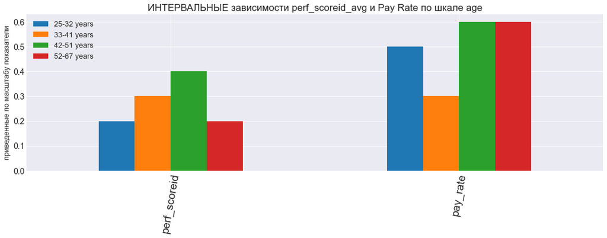

```python
plt.rcParams["figure.figsize"] = (18, 5)

matplotlib.rc('xtick', labelsize=19)
matplotlib.rc('ytick', labelsize=14)
plt.rcParams.update({'font.size': 13})

mmm.plot.bar()
plt.title("ИНТЕРВАЛЬНЫЕ зависимости perf_scoreid_avg и Pay Rate по шкале age", fontsize=17) # ШРИФТ
plt.ylabel('приведенные по масштабу показатели')
plt.xticks(rotation=80)
plt.show()
```

##### 4.5.1 Гипотезы зависимостей по шкале ВОЗРАСТ (age)

*1) Есть зависимость индекса квалификации (perf_scoreid) по шкале age: наибольшей квалификацией обладает персонал в интервале возраста 42-51 год, а наименьшей - персонал начала и конца шкалы.*  
*2) Есть зависимость ОПЛАТЫ (pay_rate) по шкале age: при прямой пропорциональной зависимости между квалификацией о оплатой в середине шкалы, присутствует повышенная (относительно квалификации) оплата в начале и конце шкалы: у молодых - IT, у старых - руководство.*